# Practica_III

Francisco Javier Ramírez Leiva

9/3/2021

```r
library(readr)
library(dplyr)
library(babynames)
library(nycflights13)
library(skimr)
library(ggplot2)
library(forcats)
```

```r
cat21 <- read_csv("elecciones_cat21_munis_longer (1).csv")
#View(cat21)
```

#Ejercicio 1. Calcula el top 10 y el bottom 10 por participación de los municipios de la provincia de Barcelona.Haz lo mismo para los municipios que no sean de la provincia de Tarragona. Muestra solo el nombre del municipio, la participación y el ganador.

```r
cat21 %>%
  filter(prov == "Barcelona") %>%
  group_by(mun, prov, participacion) %>%
  summarise(participacion = mean(participacion)) %>%
  arrange(desc(participacion)) %>%
  slice (1:10)
```

```
## # A tibble: 311 x 3
## # Groups:   mun, prov [311]
##    mun                    prov      participacion
##    <chr>                  <chr>             <dbl>
##  1 Abrera                 Barcelona          53.6
##  2 Aguilar de Segarra     Barcelona          78.0
##  3 Aiguafreda             Barcelona          60.1
##  4 Alella                 Barcelona          62.5
##  5 Alpens                 Barcelona          84.0
##  6 Ametlla del Vallès, L' Barcelona          59.5
##  7 Arenys de Mar          Barcelona          54.4
##  8 Arenys de Munt         Barcelona          56.6
##  9 Argençola              Barcelona          66.1
## 10 Argentona              Barcelona          56.7
## # ... with 301 more rows
```

```r
cat21 %>%
  group_by(mun, prov, participacion) %>%
  filter(prov == "Barcelona") %>%
  summarise(participacion_mean = mean(participacion)) %>%
  arrange(participacion) %>%
  slice (1:10)
```

```
## # A tibble: 311 x 4
## # Groups:   mun, prov [311]
##    mun                    prov      participacion participacion_mean
##    <chr>                  <chr>             <dbl>              <dbl>
##  1 Abrera                 Barcelona          53.6               53.6
##  2 Aguilar de Segarra     Barcelona          78.0               78.0
##  3 Aiguafreda             Barcelona          60.1               60.1
##  4 Alella                 Barcelona          62.5               62.5
##  5 Alpens                 Barcelona          84.0               84.0
##  6 Ametlla del Vallès, L' Barcelona          59.5               59.5
##  7 Arenys de Mar          Barcelona          54.4               54.4
##  8 Arenys de Munt         Barcelona          56.6               56.6
##  9 Argençola              Barcelona          66.1               66.1
## 10 Argentona              Barcelona          56.7               56.7
## # ... with 301 more rows
```

```r
cat21 %>%
  group_by(mun, ganador, participacion) %>%
  filter(prov ==  c("Barcelona", "Girona", "Lleida")) %>%
  summarise(participacion_mean = mean(participacion)) %>%
  arrange(desc(participacion)) %>%
  slice (1:10)
```

```
## # A tibble: 763 x 4
## # Groups:   mun, ganador [763]
##    mun                ganador participacion participacion_mean
##    <chr>              <chr>           <dbl>              <dbl>
##  1 Abella de la Conca JxCat            46.3               46.3
##  2 Abrera             PSC              53.6               53.6
##  3 Àger               JxCat            65.9               65.9
##  4 Agramunt           JxCat            55                 55
##  5 Aguilar de Segarra JxCat            78.0               78.0
##  6 Agullana           ERC              65.9               65.9
##  7 Aiguafreda         JxCat            60.1               60.1
##  8 Aiguaviva          JxCat            74.3               74.3
##  9 Aitona             PDeCAT           63.7               63.7
## 10 Alamús, Els        JxCat            64.3               64.3
## # ... with 753 more rows
```

```r
cat21 %>%
  group_by(mun, participacion, ganador) %>%
  filter(prov ==  c("Barcelona", "Girona", "Lleida")) %>%
  summarise(participacion_mean = mean(participacion)) %>%
  arrange((participacion)) %>%
  slice (1:10)
```

```
## # A tibble: 763 x 4
## # Groups:   mun, participacion [763]
##    mun                participacion ganador participacion_mean
##    <chr>                      <dbl> <chr>                <dbl>
##  1 Abella de la Conca          46.3 JxCat                 46.3
##  2 Abrera                      53.6 PSC                   53.6
##  3 Àger                        65.9 JxCat                 65.9
##  4 Agramunt                    55   JxCat                 55
##  5 Aguilar de Segarra          78.0 JxCat                 78.0
##  6 Agullana                    65.9 ERC                   65.9
##  7 Aiguafreda                  60.1 JxCat                 60.1
##  8 Aiguaviva                   74.3 JxCat                 74.3
##  9 Aitona                      63.7 PDeCAT                63.7
## 10 Alamús, Els                 64.3 JxCat                 64.3
## # ... with 753 more rows
```

#Ejercicio 2. Calcula la suma de votos nulos en los municipios en los que ganaran partidos independentistas y la participación fuese menor del 60%.

```r
cat21 %>%
  group_by(ganador, mun) %>%
  filter(ganador == c("JxCat", "ERC", "CUP")) %>%
  summarise(nulos_sum = sum(nulos), participacion_max = max(60)) %>%
  arrange(desc(nulos_sum))
```

```
## # A tibble: 830 x 4
## # Groups:   ganador [3]
##    ganador mun                    nulos_sum participacion_max
##    <chr>   <chr>                      <dbl>             <dbl>
##  1 JxCat   Girona                      2204                60
##  2 ERC     Lleida                      2160                60
##  3 ERC     Reus                        1743                60
##  4 JxCat   Sant Cugat del Vallès       1692                60
##  5 JxCat   Manresa                     1244                60
##  6 ERC     Deltebre                    1239                60
##  7 JxCat   Vilafranca del Penedès       876                60
##  8 JxCat   Igualada                     840                60
##  9 JxCat   Vic                          796                60
## 10 JxCat   Figueres                     744                60
## # ... with 820 more rows
```

#Ejercicio 3. Calcula el porcentaje de votos que habría obtenido cada partido si solo contáramos los municipios con menos de 10.000 votantes en el censo. ¿Y en cada provincia?

```r
cat21 %>%
  group_by(perc_votos, partido,mun) %>%
  filter(censo < 10000) %>%
  summarise(censo_media = mean(censo)) %>%
  arrange(desc(perc_votos))
```

```
## # A tibble: 8,520 x 4
## # Groups:   perc_votos, partido [5,159]
##    perc_votos partido mun                    censo_media
##         <dbl> <chr>   <chr>                        <dbl>
##  1       65.1 JxCat   Fontanilles                    115
##  2       64.1 JxCat   Viver i Serrateix              139
##  3       62.2 JxCat   Ivorra                         105
##  4       60.2 JxCat   Amer                          1788
##  5       58.3 JxCat   Omells de na Gaia, Els         115
##  6       58.0 JxCat   Sant Martí d'Albars             97
##  7       57.9 ERC     Fulleda                         94
##  8       57.7 JxCat   Palol de Revardit              335
##  9       57.1 JxCat   Molsosa, La                     95
## 10       57.1 JxCat   Planes d'Hostoles, Les        1272
## # ... with 8,510 more rows
```

```r
cat21 %>%
  group_by(perc_votos, partido, prov) %>%
  filter(censo < 10000) %>%
  summarise(censo_media2 = mean(censo)) %>%
  arrange(desc(perc_votos))
```

```
## # A tibble: 6,740 x 4
## # Groups:   perc_votos, partido [5,159]
##    perc_votos partido prov      censo_media2
##         <dbl> <chr>   <chr>            <dbl>
##  1       65.1 JxCat   Girona             115
##  2       64.1 JxCat   Barcelona          139
##  3       62.2 JxCat   Lleida             105
##  4       60.2 JxCat   Girona            1788
##  5       58.3 JxCat   Lleida             115
##  6       58.0 JxCat   Barcelona           97
##  7       57.9 ERC     Lleida              94
##  8       57.7 JxCat   Girona             335
##  9       57.1 JxCat   Girona            1272
## 10       57.1 JxCat   Lleida              95
## # ... with 6,730 more rows
```

#Ejercicio 4. Calcula la participación media entre los municipios de cada provincia y la participación real en cada provincia. Repite este mismo cálculo solo en los municipios en los que haya ganado Junts Per Catalunya.

```r
colores_prov <- c("red", "orange", "purple", "yellow")
names(colores_prov) <- c("Girona", "Lleida", "Tarragona", "Barcelona")

cat21 %>%
  group_by(mun, prov, ganador) %>%
  summarise(participacion_media = mean(participacion))
```

```
## # A tibble: 947 x 4
## # Groups:   mun, prov [947]
##    mun                prov      ganador participacion_media
##    <chr>              <chr>     <chr>                 <dbl>
##  1 Abella de la Conca Lleida    JxCat                  46.3
##  2 Abrera             Barcelona PSC                    53.6
##  3 Àger               Lleida    JxCat                  65.9
##  4 Agramunt           Lleida    JxCat                  55
##  5 Aguilar de Segarra Barcelona JxCat                  78.0
##  6 Agullana           Girona    ERC                    65.9
##  7 Aiguafreda         Barcelona JxCat                  60.1
##  8 Aiguamúrcia        Tarragona ERC                    54.7
##  9 Aiguaviva          Girona    JxCat                  74.3
## 10 Aitona             Lleida    PDeCAT                 63.7
## # ... with 937 more rows
```

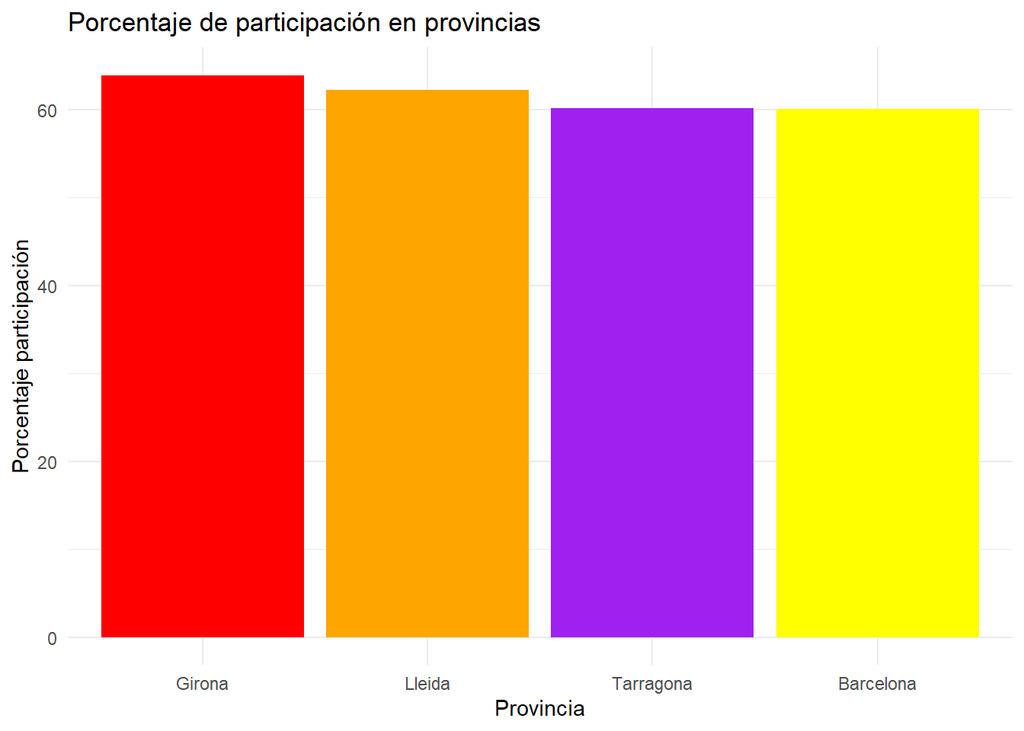

```r
cat21 %>%
  group_by(prov) %>%
  summarise(participacion_media = mean(participacion)) %>%
  ggplot() +
  geom_col(mapping = aes(x = fct_reorder(prov, desc(participacion_media)), y = participacion_media, fill = prov), show.legend = F) +
  scale_fill_manual(values = colores_prov) +
  theme_minimal() +
  labs(x = "Provincia", y = "Porcentaje participación", title = "Porcentaje de participación en provincias")
```

```r
cat21 %>%
  filter(ganador == "JxCat") %>%
  group_by(mun, prov) %>%
  summarise(participacion_media = mean(participacion))
```

```
## # A tibble: 571 x 3
## # Groups:   mun [571]
##    mun                prov      participacion_media
##    <chr>              <chr>                   <dbl>
##  1 Abella de la Conca Lleida                   46.3
##  2 Àger               Lleida                   65.9
##  3 Agramunt           Lleida                   55
##  4 Aguilar de Segarra Barcelona                78.0
##  5 Aiguafreda         Barcelona                60.1
##  6 Aiguaviva          Girona                   74.3
##  7 Alamús, Els        Lleida                   64.3
##  8 Alàs i Cerc        Lleida                   63.7
##  9 Albanyà            Girona                   68.8
## 10 Albi, L'           Lleida                   69.5
## # ... with 561 more rows
```

#Ejercicio 5. Representa en un gráfico la relación entre la participación y el voto a Ciudadanos en los municipios de la provincia de Barcelona.

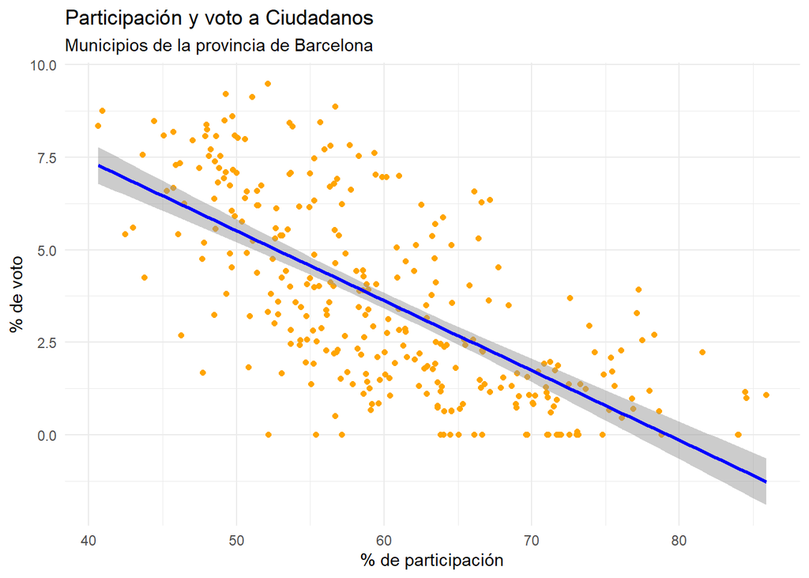

```r
cat21 %>%
  select(mun, prov, participacion, partido, perc_votos) %>%
  filter(prov == "Barcelona", partido == "Cs") %>%
  ggplot() +
  geom_point(mapping = aes(x = participacion, y = perc_votos), color = "orange") +
  geom_smooth(aes(x = participacion, y = perc_votos), color = "blue", alpha = 0.5, method = "lm") +
  theme_minimal() +
  labs(x = "% de participación", y = "% de voto", title = "Participación y voto a Ciudadanos", subtitle = "Municipios de la provincia de Barcelona")
```

#Ejercicio 6. Representa en un gráfico de barras el número total de votos que ha obtenido cada partido en la provincia de Girona.

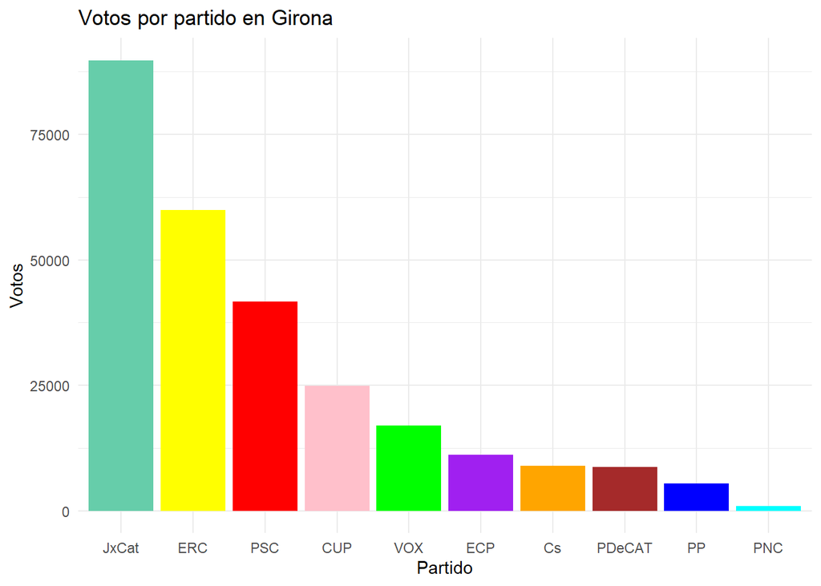

```r
colores <- c("red", "orange", "purple", "green", "yellow", "blue", "brown", "mediumaquamarine", "pink", "cyan" )
names(colores) <- c("PSC", "Cs", "ECP", "VOX", "ERC", "PP", "PDeCAT", "JxCat", "CUP", "PNC")

cat21 %>%
  select(mun, prov, partido, votos_partido) %>%
  filter(prov == "Girona") %>%
  group_by(partido) %>%
  summarise(total = sum(votos_partido)) %>%
  ggplot() +
  geom_col(mapping = aes(x = fct_reorder(partido, desc(total)), y = total, fill = partido), show.legend = F) +
  scale_fill_manual(values = colores) +
  theme_minimal() +
  labs(x = "Partido", y = "Votos", title = "Votos por partido en Girona")
```